# Лабораторная работа №16

Программный RAID (mdadm)

Ришард Когенгар

Российский университет дружбы народов, Москва, Россия

22 января 2026

# Цель работы

## Основная цель

Освоить создание и администрирование программных RAID-массивов в Linux с использованием утилиты **mdadm**.

# Ход выполнения работы

## Создание виртуальных носителей

- Открыт раздел **Носители** в настройках ВМ
- К контроллеру **SATA** добавлены **3 диска по 512 MiB**
- Формат: **VDI**, тип: **динамический**

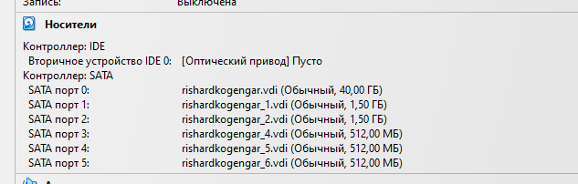

Подключение дополнительных виртуальных дисков к контроллеру SATA

## Проверка наличия дисков в системе

- Получены права администратора (**root**)
- Проверено появление устройств `/dev/sdd`, `/dev/sde`, `/dev/sdf`

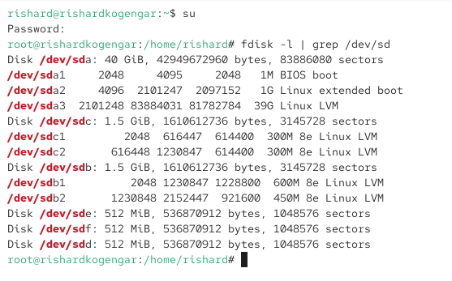

Проверка наличия добавленных дисков /dev/sdd, /dev/sde, /dev/sdf

## Создание разделов на дисках

- На каждом диске создан один раздел:
  - `/dev/sdd1`, `/dev/sde1`, `/dev/sdf1`
- Разметка выполнена утилитой **sfdisk**

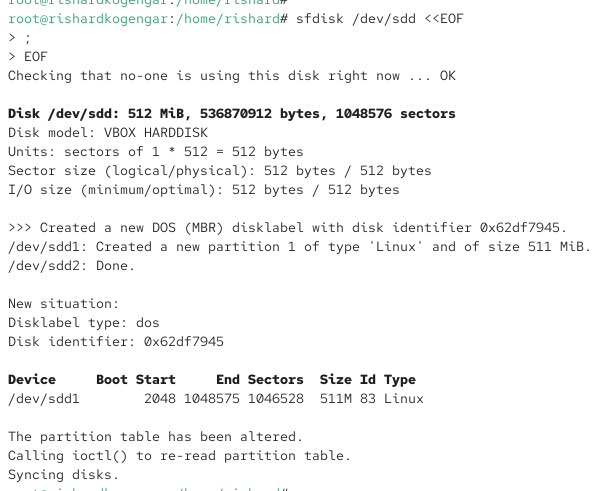

Создание раздела на диске /dev/sdd с помощью sfdisk

## Проверка типа разделов и RAID-типы

- Тип новых разделов по умолчанию: **83 (Linux)**
- Просмотр доступных RAID-типов партиций
- Подготовка к включению в RAID

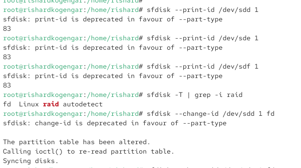

Проверка типа разделов и изменение на Linux raid autodetect (fd)

## Установка типа Linux raid autodetect (fd)

- Тип разделов изменён на **fd**
- Цель: корректная идентификация разделов как RAID-совместимых

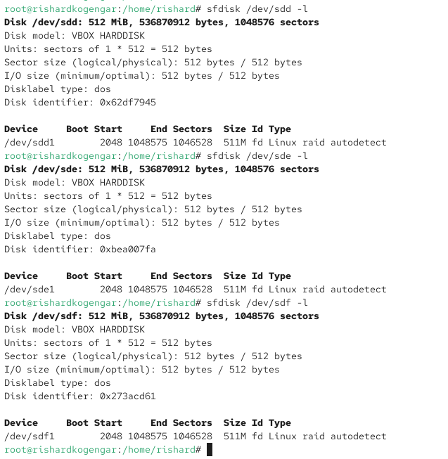

Состояние дисков после изменения типа разделов на fd

## Создание RAID 1 массива

- Создан массив **RAID 1**:
  - устройство массива: `/dev/md0`
  - диски: `/dev/sdd1` и `/dev/sde1`
- Выполнена первичная проверка состояния массива

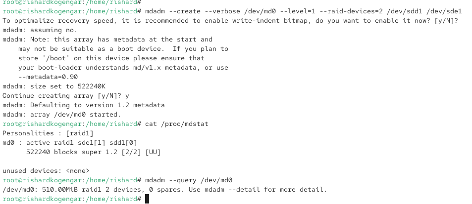

Создание RAID1 и проверка состояния через /proc/mdstat и mdadm –query

## Детальная проверка массива RAID 1

- Массив в состоянии **clean**
- Устройства:
  - `/dev/sdd1` — active sync
  - `/dev/sde1` — active sync

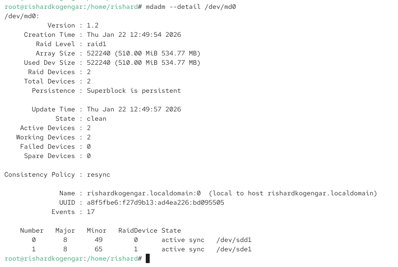

Детальная информация о массиве md0

## Файловая система и монтирование

- Создана файловая система **ext4** на `/dev/md0`
- Монтирование выполнено в каталог `/mnt/raid`

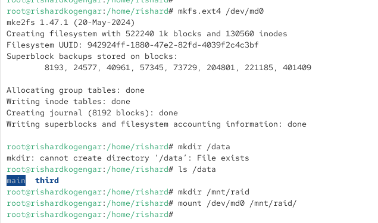

Создание файловой системы ext4 и монтирование массива

## Автомонтирование через /etc/fstab

- Добавлена запись для автомонтирования:
  - устройство: `/dev/md0`
  - точка монтирования: `/mnt/raid`
  - тип: `ext4`, параметры: `defaults 1 2`

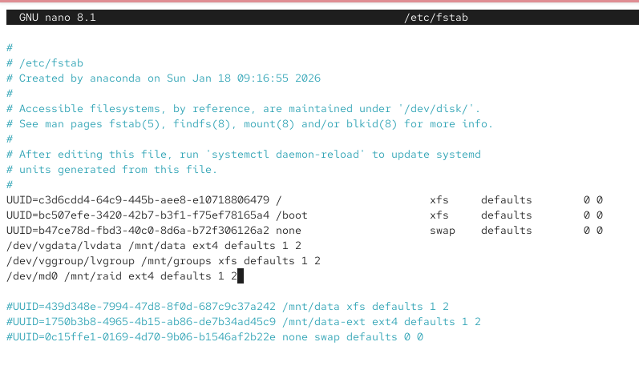

Добавление записи для автомонтирования в /etc/fstab

## Имитация отказа и восстановление RAID 1

- Смоделирован отказ `/dev/sde1`
- Сбойный диск удалён из массива
- В массив добавлен третий диск `/dev/sdf1`
- Итог: массив восстановлен и работоспособен

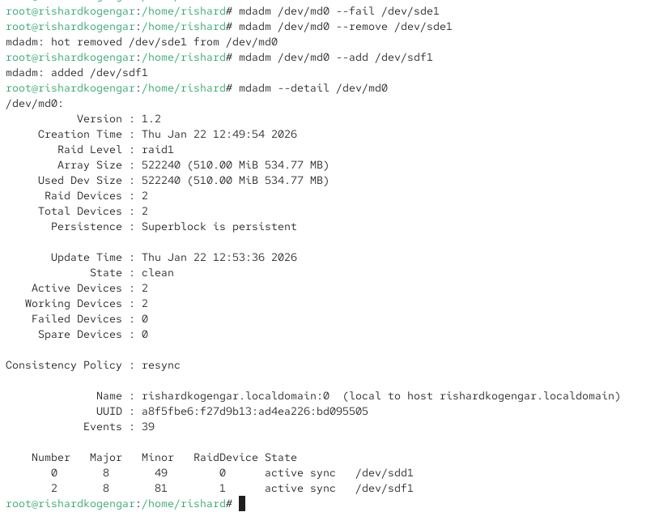

Имитация отказа, удаление диска и добавление нового устройства в RAID

## Остановка массива и очистка метаданных

- Массив размонтирован и остановлен
- Метаданные RAID очищены командой `--zero-superblock`

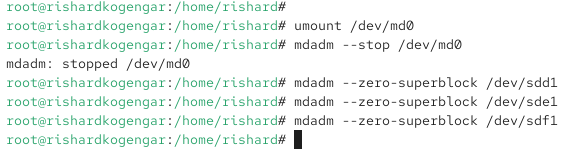

Остановка массива и очистка RAID-метаданных

## Создание RAID 1 + добавление hotspare

- Создан RAID 1: `/dev/sdd1` + `/dev/sde1` → `/dev/md0`
- Добавлен горячий резерв: `/dev/sdf1` (spare)
- Проверка показывает наличие **2 devices + 1 spare**

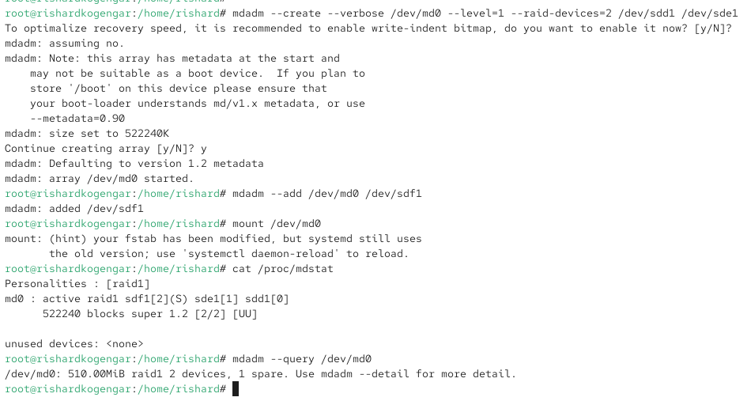

Создание RAID1, добавление hotspare и проверка состояния

## Состояние массива с hotspare

- Активные устройства:
  - `/dev/sdd1` — active sync
  - `/dev/sde1` — active sync
- Резервное устройство:
  - `/dev/sdf1` — spare
- Состояние массива: **clean**

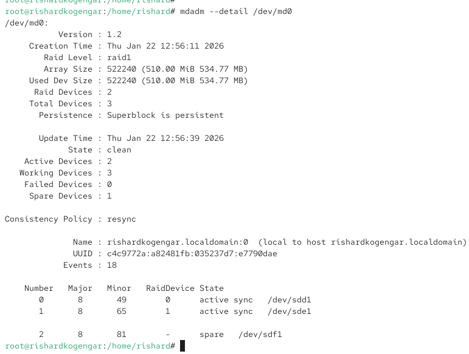

Состояние массива md0: два active sync и один spare

## Отказ диска и автоматическая замена hotspare

- Смоделирован отказ `/dev/sde1`
- Hotspare `/dev/sdf1` автоматически перешёл в **active sync**
- Отказавший диск отображается как **faulty**
- Работоспособность массива сохранена

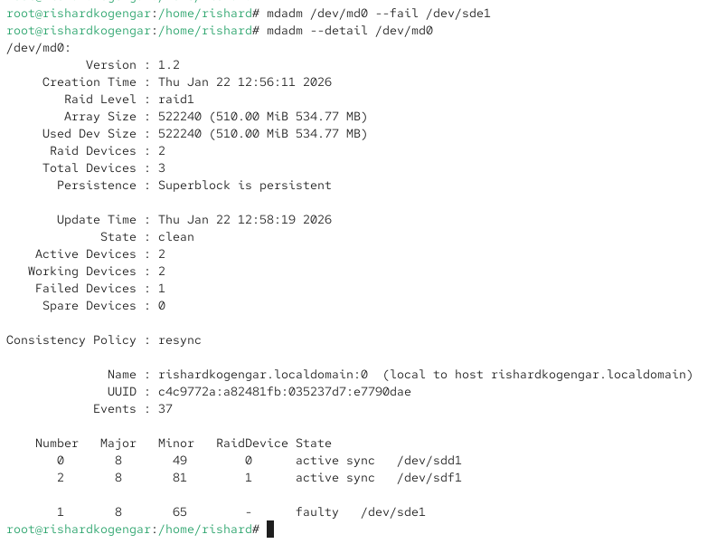

Имитация отказа диска и автоматическая замена hotspare

## Состояние перед преобразованием

- RAID 1 создан на `/dev/sdd1` и `/dev/sde1`
- `/dev/sdf1` добавлен как spare
- Массив корректен и готов к преобразованию

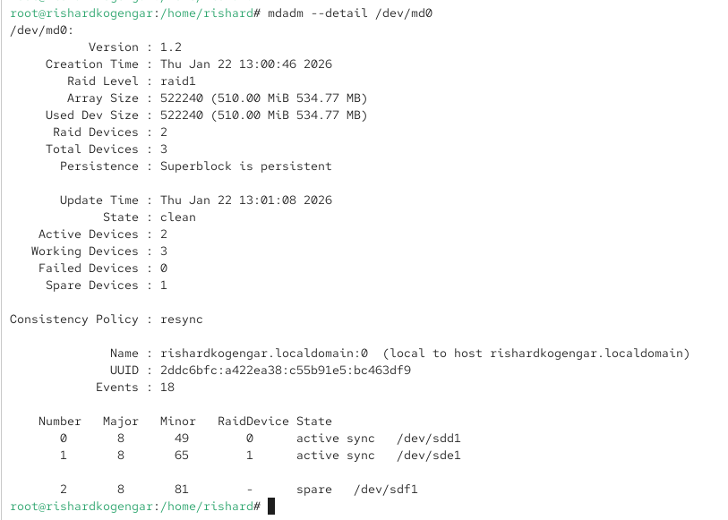

Проверка состояния массива RAID1 перед преобразованием

## Смена уровня массива на RAID 5

- Выполнено преобразование уровня:
  - `--grow --level=5`
- В выводе отображаются параметры RAID 5:
  - layout: **left-symmetric**
  - chunk size: **64K**

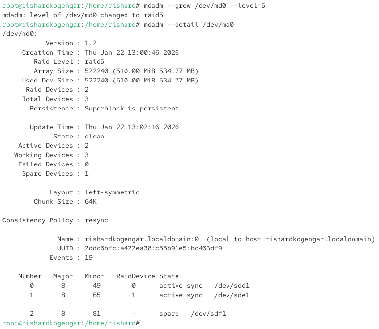

Изменение уровня массива на RAID5 и проверка mdadm –detail

## Увеличение числа дисков до 3

- Установлено количество устройств:
  - `--grow --raid-devices=3`
- Все три диска активны (**active sync**)
- Размер массива увеличен (≈ **1020 MiB**)
- Состояние массива: **clean**

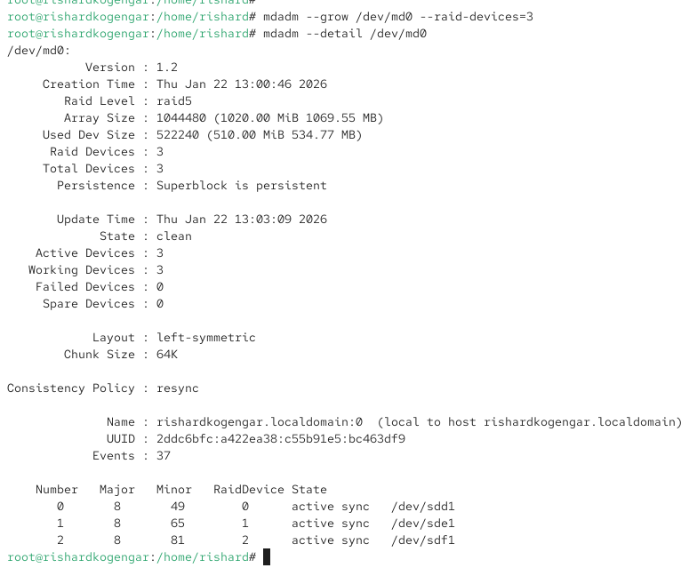

RAID5 после увеличения числа устройств до 3

# Итоги работы

## Вывод

- Освоено создание и контроль RAID с помощью **mdadm**
- Создан и проверен **RAID 1** (включая отказ и восстановление)
- Реализован сценарий **hotspare** с автоматической заменой диска
- Выполнено преобразование **RAID 1 → RAID 5** и расширение массива
- Проведена корректная остановка массивов и очистка метаданных